# Natural Language Processing

Sentiment Analysis and Topic Modeling

## Overview

This page presents NLP analysis addressing 4 NLP business questions through sentiment analysis, topic modeling, and text mining.

## City Dialect

### Business Question 1:

**Questions**: Which words indicate the distinct dialect/slang for each city?

### Overall Findings

[figure not shown]

Fig 6. City Dialect Frequency Heatmap

The heatmap above shows the top 15 city-unique words by frequency for each city. Words are ranked by their raw count within each city, showing which terms are most commonly used in city-specific discussions.

**Key Observations:**

- Each city has a distinct set of unique words that don’t appear in other cities’ subreddits
- The filtering successfully removed common words like “traffic”, “parking”, and other terms that would appear across multiple cities
- Many top terms are neighborhood names, local institutions, and city-specific subreddits, reflecting the local focus of each city’s Reddit communities

### Top Words by Frequency

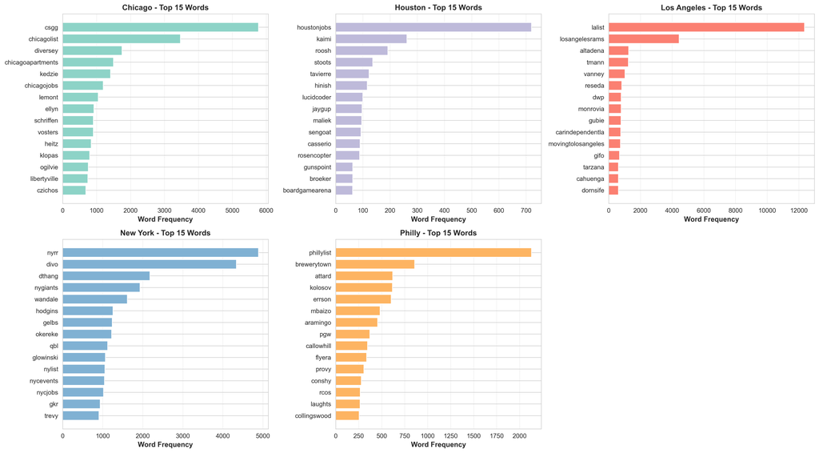

Fig 7. Top City-Unique Words by City

The bar charts above display the top 15 city-unique words ranked by frequency for each city. This visualization highlights the most commonly used distinctive terms in each city’s subreddit discussions.

### TF-IDF Analysis

[figure not shown]

Fig 8. TF-IDF Heatmap

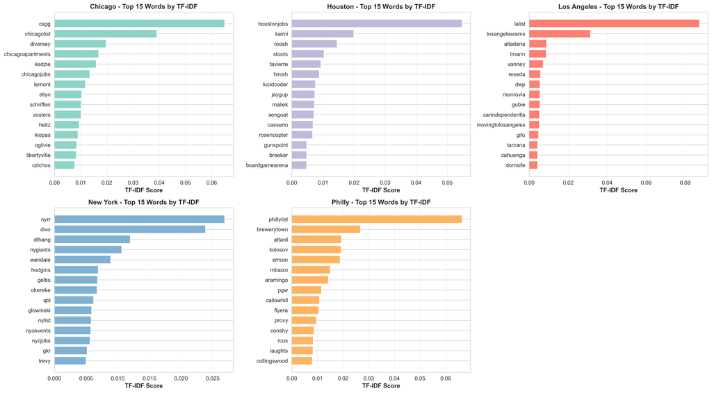

Fig 9. TF-IDF by City

TF-IDF (Term Frequency-Inverse Document Frequency) scoring helps identify words that are both frequent within a city and rare across all cities. This metric highlights terms that are highly distinctive to each city’s dialect.

**TF-IDF Insights:**

- Words with high TF-IDF scores are the most distinctive markers of each city’s dialect
- Neighborhood names and local institutions consistently score high, indicating strong local identity markers
- The TF-IDF analysis confirms that each city has a unique linguistic fingerprint in their Reddit communities
- Some terms appear frequently in one city but are completely absent from others, demonstrating successful filtering of overlapping words

## Vulgarity Analysis

### Business Question 2:

**Question:** Which city uses the most vulgar language?

### Overall Findings

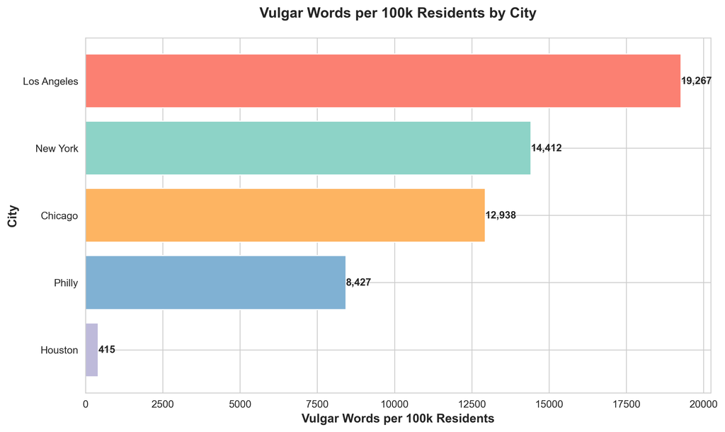

Fig 10. Vulgar Words By Population

**Key Observations**

This chart shows the number of vulgar words across the whole dataset, normalized by the populations of the cities. It shows that LA has the most cursing by a long shot. Houston has the least. Overall, this could indicate differences in dialect. It could also indicate that certain cities have stronger moderation on their subreddits than others.

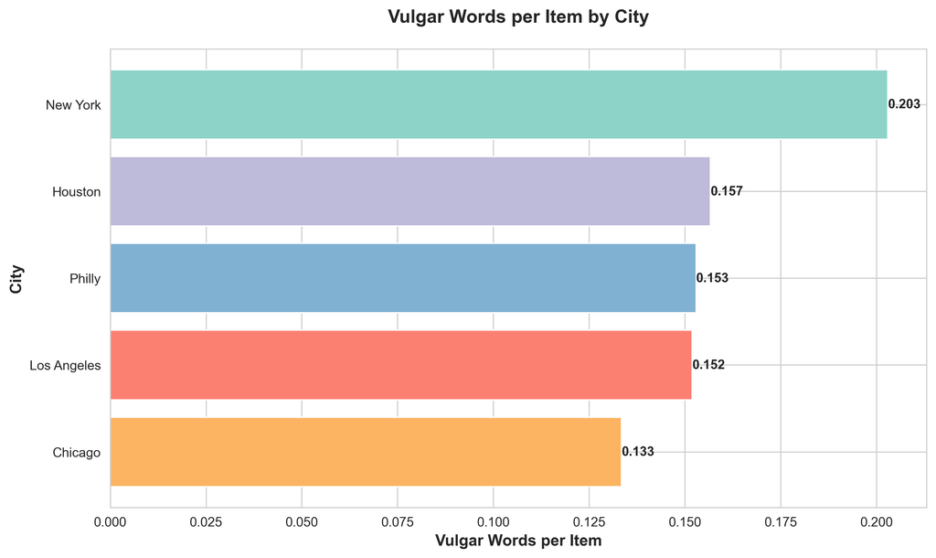

Fig 11. Vulgar Words By Item

**Key Observations**

This graph indicates the number of vulgar words per post for each city. Interestingly, it shows that despite the Houston subreddits having the least amount of cursing, they have a higher rate of cursing per post than most cities. New York is the highest overall and Chicago is the lowest.

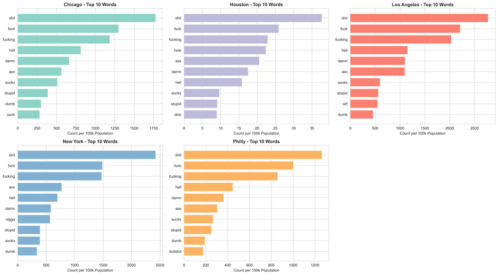

Fig 12. Top 10 Vulgar Words By City

**Key Observations**

Many of the top 10 curse words used across the subreddits are very similar. Houston seems to use language that is more sexual in nature. Philadelphia, on the other hand, appears to have words that are more insulting.

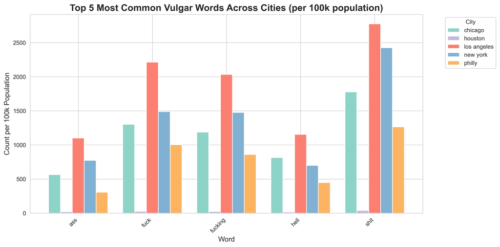

Fig 13. Top 5 Vulgar Words Compared City

**Key Observations**

When we compare the usage of the most common curse words across the cities (normalized by population), Houston tends to use them way less than the others. LA comes out on top across the board. Also, the proportions are very similar between the words, indicating that reddit users speak similarly regardless of city.

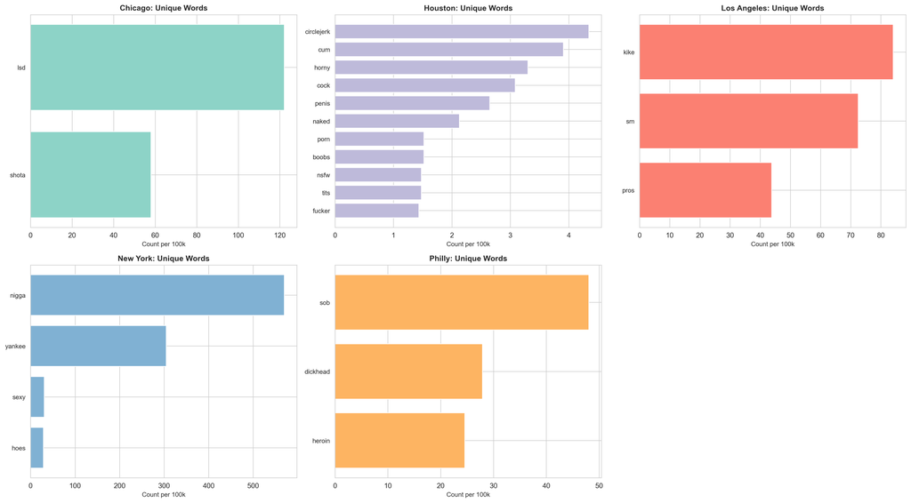

Fig 14. Top Unique Vulgar Words By City

**Key Observations**

After removing the shared words in the top 50 most used words between the cities, these words displayed in these graphs remained. Houston has the most diversity in vulgar language, with a lot of the leftover words being sexual in nature. Philly’s words are words commonly used as insults. Some of the words reveal antisemtic, racist, and pedophilic language getting past moderators in these states.

## Sentiment Analysis

### Business Question 3:

**Question:** How does sentiment change for posts regarding sports for each city based on how poor the cities’ NBA team is performing?

### Overall Sentiment Findings

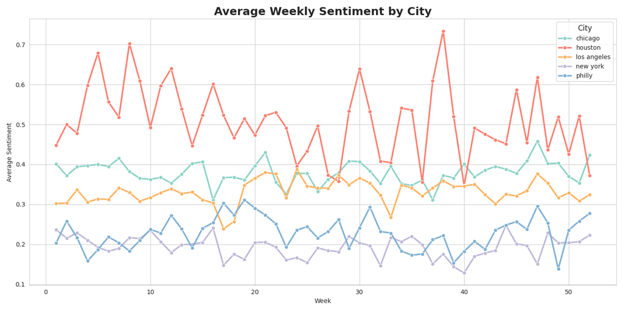

Fig 15. Overall Sentiment

The above figure 15 displays the average weekly sentiment for each city for all subreddits and topics. A value of -1 indicates a very negative average sentiment, while a value of 1 indicates a very positive average sentiment, with 0 indicating a neutral sentiment.

As the plot above shows, the **average sentiment for each city is quite unique**. For instance, Houston maintains the highest positivity, typically ranging from 0.5 to 0.6. In contrast, New York shows the most neutral sentiment, consistently around 0.15 to 0.2, with Philadelphia close behind. Los Angeles and Chicago fall in the middle range, typically between 0.3 to 0.4 throughout most of the year.

Overall, the plot indicates that the posts and language of Reddit within these cities is **neutral, but slightly positive** with Houston being the most consistently positive city.

### NBA Sentiment Findings

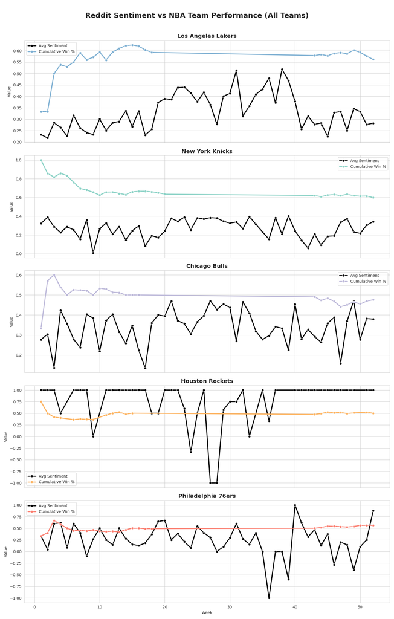

Fig 16. Sentiment and Win Percentage

## Topic Modeling

### Business Question 4:

**Question:** What are the most talked about topics in each city?

### Discovered Topics

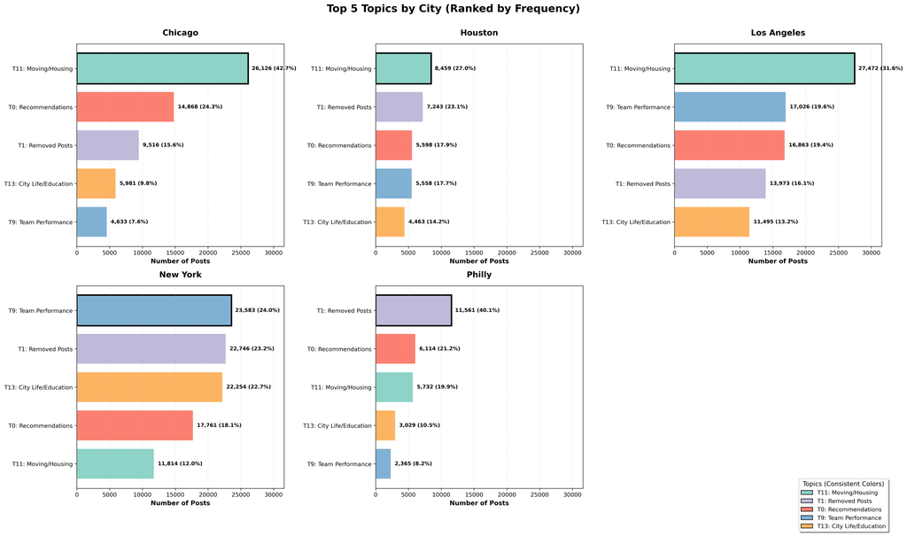

Fig 17. Top Topics by City

The bar chart explores what topics are the most submitted for each city’s subreddits. The top 5 topics discovered for each city using LDA topic modeling. The topics were labeled based on the top keywords associated with each topic.

**Table 2. Topic Model Results**

| Topic | Label | Top Keywords |
| --- | --- | --- |
| 0 | Recommendations | best, good, food, parking, recommendations, looking, place |
| 1 | Removed Posts | removed, new, nyc, york, philly, chicago, day, man, help, white |
| 2 | Houston Q&A | anyone, houston, know, get, take, like, class |
| 3 | Daily Threads | thread, daily, discussion, post, use, chicago, body, please |
| 4 | NBA/Basketball | lakers, pick, draft, removed, trade, nba, jersey, view |
| 5 | Game Threads | game, yankees, flyers, edt |
| 6 | Baseball Season | game, mets, season, dodgers, team, deleted, day, stadium, games |
| 7 | Conversation | like, get, think, year, one, time, even, people |
| 8 | Tickets/Events | tickets, ticket, selling, tonight, removed, show, free, sale |
| 9 | Team Performance | game, team, get, like, play, back, go, games, good |
| 10 | Personal Stories | one, year, time, years, today, last, first, dog, good, went |
| 11 | Moving/Housing | looking, like, area, know, chicago, city, want |
| 12 | Baseball Stats | video, game, scores, era, spacer, score, run |
| 13 | City Life/Education | people, like, city, get, nyc, los, school, angeles, students |
| 14 | News/Development | new, video, york, development, project, data |

### Key Insights:

- All the cities have the same 5 top topics most frequently appear in their submission posts out of the 15 total discovered topics
- Moving/Housing is the most popular topic in Chicago, Houston, and Los Angeles. This topic is driven by discussions around posts discussing “looking”, “like”, “area”, “know”, and “city”, indicating that lots of subreddit users are looking to gain insight about a certain area of the city, possibly for moving or housing purposes.
- Team Performance is the most popular topic in New York. Team performance topic are driven by discussions around posts discussing “game”, “team”, “play”, and “good”, indicating that users are focused on how well their teams are performing.
- Removed Posts is the most popular topic in Philadelphia. The removed psosts topic likely indicates a high level of moderation in the Philadelphia subreddit. Even though there are some other keywords appearing in this topic category, the dominant word “removed” accoutns for 0.24 of the topic weight, which is significantly higher than the next highest word “new” at 0.02

## Summary

### Key Takeaways

- Neighborhood names and local institutions are the strongest dialect markers, showing that Reddit users have strong geographic identity and connections to their local communities.
- Some city’s use more diverse vulgar language while others stick to the typical words and the categories of these words can classify the cities’ residents’ behavior online.

**Tip**

All NLP code is in `code/nlp/` directory.